# Week 1 Problem Set

Emily K. Power

2023-02-15

#### Create an object in R that is a vector of the distances everyone has moved to get to Middlebury.

```r
# load in data
distanceData <- read.table(file="/Users/emilypower/Desktop/BIOL_0211A/Data/Distance_to_Middlebury_Data.csv", header=TRUE, sep=",")
head(distanceData)
```

```
##   Class.Member Distance.Moved.to.Middlebury..km.
## 1        Moody                           1677.00
## 2      Atallah                            252.81
## 3        Breen                            232.84
## 4 Como-Mosconi                           2921.72
## 5  DeFrancesco                            215.00
## 6      Dlamini                          13135.92
```

```r
# make vector object
distanceVector <- c(distanceData$Distance.Moved.to.Middlebury..km.)
distanceVector
```

```
##  [1]  1677.000   252.810   232.840  2921.720   215.000 13135.920  4005.510
##  [8]   344.250   741.060    19.360  3478.000   348.000   525.934  4914.800
## [15]   232.690   341.910  1068.300   363.360   267.170    23.710  3265.120
## [22]   226.250  2389.640 10553.580   278.000   242.740
```

#### Convert those distances from km to furlongs (1 km = 4.97 furlongs). What is the largest value in this new vector?

```r
# multiply by scale factor
distanceFurlongs <- distanceVector*4.97

# print new values
distanceFurlongs
```

```
##  [1]  8334.6900  1256.4657  1157.2148 14520.9484  1068.5500 65285.5224
##  [7] 19907.3847  1710.9225  3683.0682    96.2192 17285.6600  1729.5600
## [13]  2613.8920 24426.5560  1156.4693  1699.2927  5309.4510  1805.8992
## [19]  1327.8349   117.8387 16227.6464  1124.4625 11876.5108 52451.2926
## [25]  1381.6600  1206.4178
```

```r
# largest value is 65285.5224 furlongs
```

#### Is the dataset we have collected a random sample of the population of students at Middlebury College?

- No. This is not a random sample of the population of students at Middlebury because it was taken from a specific biology class. The hometowns of biology majors at Middlebury may not be representative of the general population. If we were to collect a random sample of the population, we’d have to expand our search across majors and locations on campus.

#### Looking for an Extra Challenge?

- Save the file as a .csv from the Google Sheet and load it into R.
- Create a second object that is a character variable with multiple categories like A or B (you can make up whatever you want). Then create a dataframe or tibble by adding the data we collected to this new variable.

```r
# what does this mean?
```

- Add the column of distance in furlongs as a separate column to your dataframe or tibble (hint: use the mutate function).

```r
library(tidyverse)
distanceDF <- data.frame(distanceData) %>%  # create data frame from data
  mutate(Distance.Moved.to.Middlebury..furlongs. = Distance.Moved.to.Middlebury..km.*4.97)  # add furlongs column
head(distanceDF)
```

```
##   Class.Member Distance.Moved.to.Middlebury..km.
## 1        Moody                           1677.00
## 2      Atallah                            252.81
## 3        Breen                            232.84
## 4 Como-Mosconi                           2921.72
## 5  DeFrancesco                            215.00
## 6      Dlamini                          13135.92
##   Distance.Moved.to.Middlebury..furlongs.
## 1                                8334.690
## 2                                1256.466
## 3                                1157.215
## 4                               14520.948
## 5                                1068.550
## 6                               65285.522
```

- Use the spread function to convert your dataset into “wide” format. You can use the gather function to bring it back to “long” format. Which format is easier to work with in R, the original “long” format or the new “wide” format?

```r
# spread data
wideDF <- distanceDF %>%
  spread(key=Class.Member, value=Distance.Moved.to.Middlebury..km.)
head(wideDF)
```

```
##   Distance.Moved.to.Middlebury..furlongs. Atallah  Breen Como-Mosconi
## 1                                 96.2192      NA     NA           NA
## 2                                117.8387      NA     NA           NA
## 3                               1068.5500      NA     NA           NA
## 4                               1124.4625      NA     NA           NA
## 5                               1156.4693      NA     NA           NA
## 6                               1157.2148      NA 232.84           NA
##   DeFrancesco Dlamini Edwards Fink Forbes Gramling Gyeltshen Henning Lieb Louie
## 1          NA      NA      NA   NA     NA    19.36        NA      NA   NA    NA
## 2          NA      NA      NA   NA     NA       NA        NA      NA   NA    NA
## 3         215      NA      NA   NA     NA       NA        NA      NA   NA    NA
## 4          NA      NA      NA   NA     NA       NA        NA      NA   NA    NA
## 5          NA      NA      NA   NA     NA       NA        NA      NA   NA    NA
## 6          NA      NA      NA   NA     NA       NA        NA      NA   NA    NA
##   Moody Munroe Peebles Porter Power Romani Rooney Rossbach Surapaneni Thompson
## 1    NA     NA      NA     NA    NA     NA     NA       NA         NA       NA
## 2    NA     NA      NA     NA    NA     NA  23.71       NA         NA       NA
## 3    NA     NA      NA     NA    NA     NA     NA       NA         NA       NA
## 4    NA     NA      NA     NA    NA     NA     NA       NA     226.25       NA
## 5    NA 232.69      NA     NA    NA     NA     NA       NA         NA       NA
## 6    NA     NA      NA     NA    NA     NA     NA       NA         NA       NA
##   Tsubouchi Vikstrom Welsh
## 1        NA       NA    NA
## 2        NA       NA    NA
## 3        NA       NA    NA
## 4        NA       NA    NA
## 5        NA       NA    NA
## 6        NA       NA    NA
```

```r
# gather data
longDF <- wideDF %>%
  gather(key=Class.Member, value=Distance.Moved.to.Middlebury..km.)

# I didn't do this right
```

- Try using ggplot2 to create a histogram of the dataset on distance moved to Middlebury. What features does the distribution have?

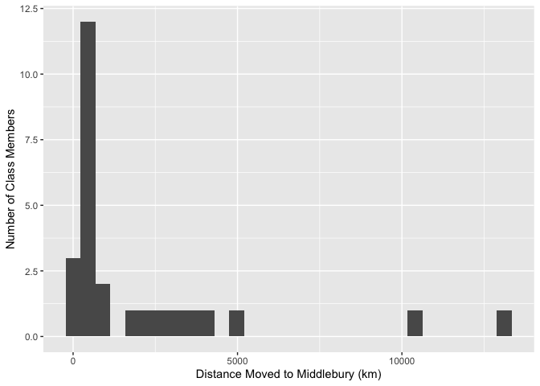

```r
# load library
library(ggplot2)

# generate histogram
distanceHistogram <- ggplot(distanceDF, aes(x=Distance.Moved.to.Middlebury..km.)) +
  geom_histogram() +
  xlab("Distance Moved to Middlebury (km)") +
  ylab("Number of Class Members")
distanceHistogram
```